# Estudio sobre el cáncer de pulmón

# 1. Introducción

Según datos de la Sociedad Española de Oncología Médica (SEOM), el cáncer de pulmón es el tercer tumor más frecuente, tanto en hombres como en mujeres, además de constituirse como el tumor con mayor mortalidad globalmente.

Unas cifras ante las cuales es fundamental un diagnóstico precoz. El diagnóstico cuando no hay invasión de estructuras vecinas ni metástasis a distancia resulta esencial para poder conseguir la curación de este cáncer hasta en un 90% de los pacientes.

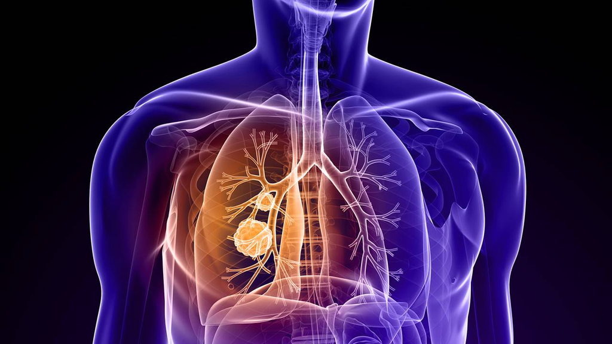

Cancer de pulmón

El cáncer de pulmón surge por la proliferación exagerada y sin control de determinadas células del pulmón. Además, puede diseminarse a otros órganos (metástasis a distancia).

Existen dos tipos principales de tumor: el carcinoma de células no pequeñas (85% de los casos) y el carcinoma de células pequeñas o carcinoma microcítico de pulmón (15% de los casos).

# 2. Set de datos

Este es un conjunto de datos de análisis de supervivencia estándar del libro de texto clásico de Kalbfleisch y Prentice, de un ensayo aleatorizado de dos regímenes de tratamiento para el cáncer de pulmón.

| therapy | cell | t | dead | kps | diagtime | age | prior |
| --- | --- | --- | --- | --- | --- | --- | --- |
| standard | Squamous | 72 | dead | 60 | 7 | 69 | no |
| standard | Squamous | 411 | dead | 70 | 5 | 64 | yes |
| standard | Squamous | 228 | dead | 60 | 3 | 38 | no |
| standard | Squamous | 126 | dead | 60 | 9 | 63 | yes |
| standard | Squamous | 118 | dead | 70 | 11 | 65 | yes |
| standard | Squamous | 10 | dead | 20 | 5 | 49 | no |
| standard | Squamous | 82 | dead | 40 | 10 | 69 | yes |
| standard | Squamous | 110 | dead | 80 | 29 | 68 | no |
| standard | Squamous | 314 | dead | 50 | 18 | 43 | no |
| standard | Squamous | 100 | censored | 70 | 6 | 70 | no |

[output cut: 127 more lines]

## 2.1. Descripción del dataset

Cada una de las columnas de `valung` representa un parámetro medido a cada paciente:

| columna | descripción |
| --- | --- |
| `therapy` | tipo de tratamiento aplicado a cada paciente, 2 tipos: test y standard |
| `cell` | tipo de célula de cancer de pulmón |
| `t` | tiempo de seguimiento del tratamiento (días) |
| `dead` | supervivencia o no para dicho `diagtime` |
| `kps` | desempeño de Karnofsky, que evalúa la calidad de vida del paciente (0=malo, 100=muy bueno) |
| `diagtime` | tiempo desde el diagnóstico hasta la aleatorización (meses) |
| `age` | edad del paciente |
| `prior` | Terapia previa (0=no, 1=sí) |

## 2.2. Cuestiones a resolver

Las preguntas que queremos responder son:

¿Qué tipo de células cancerígenas es más agresiva para el cuerpo?

¿Cómo influye el tiempo de diagnóstico? Y una vez diagnosticado, ¿cómo influye una actuación rápida?

¿Se aplica algún criterio para elegir el tipo de tratamiento?

# 3. Análisis de los tipos de células cancerígenas

En esta gráfica vemos que tipo de células cancerígenas (`type`) son más frecuentes:

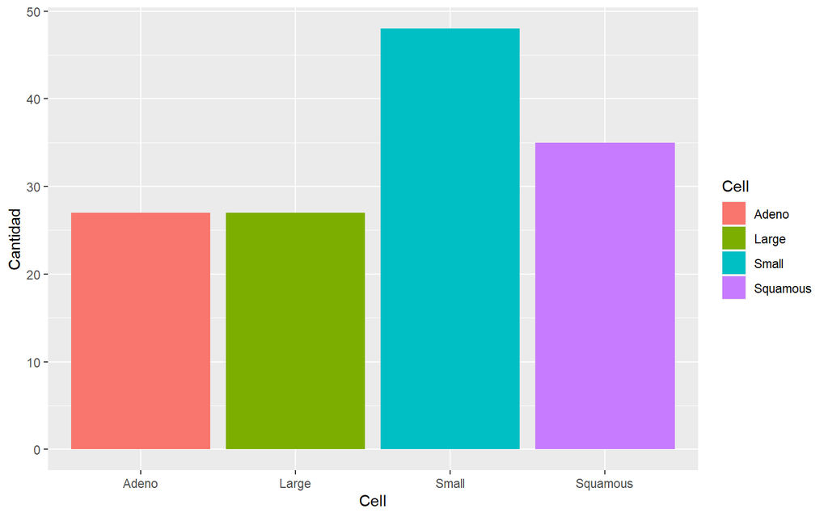

## 3.1. Test de proporciones iguales entre tipos células

Los test de proporciones iguales sirven para comparar la igualdad en las proporciones dentro de 2 muestras. Siendo la hipótesis nula que tienen la misma proporción, es decir, en nuestro ejemplo queremos ver si la relación censored-dead es la misma entre los distintos tipos de células.

### Adeno y large

[output not shown]

```r
barplot(survival, beside=T, col=c("darkolivegreen3","indianred1"), ylab="Número de personas")
legend("topright", inset=.02, legend=c("dead","censored"), fill=c("darkolivegreen2", "indianred1"))
```

[output not shown]

```r
prop.test(survival2, alternative="less",conf.level = 0.95)
```

[output not shown]

El p.value no es significativo, por tanto aceptamos la hipótesis nula, es decir tenemos la misma proporción en los 2 tipos de célula.

### Adeno y small

```
##          adeno small
## dead        11    19
## censored    16    29
```

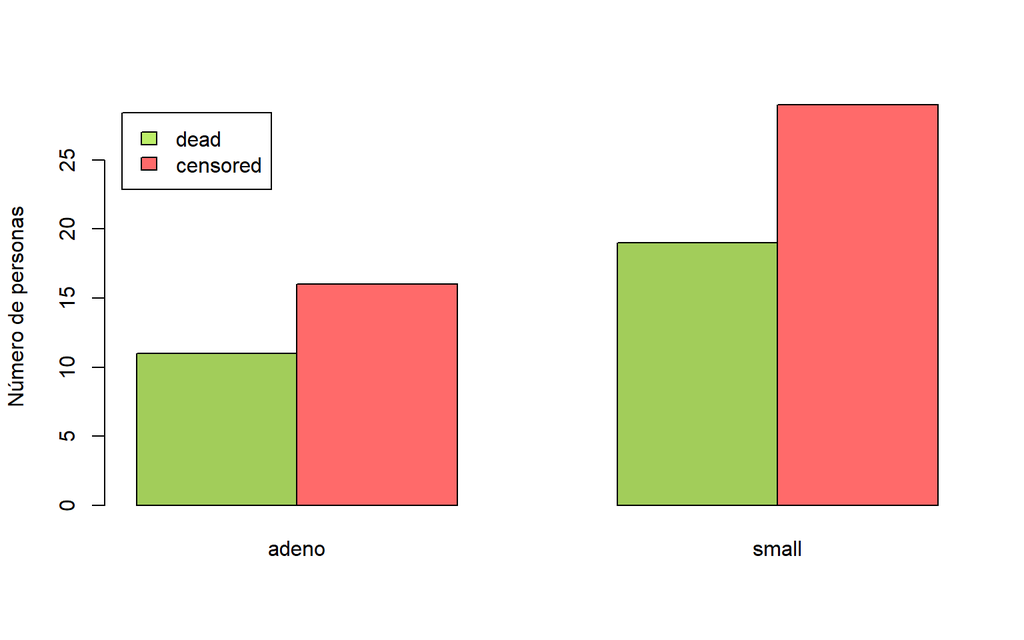

```r
barplot(survival3, beside=T, col=c("darkolivegreen3","indianred1"), ylab="Número de personas")
legend("topleft", inset=.02, legend=c("dead","censored"), fill=c("darkolivegreen2", "indianred1"))
```

```r
prop.test(survival3, alternative="less",conf.level = 0.95)
```

```
##
##  2-sample test for equality of proportions with continuity correction
##
## data:  survival3
## X-squared = 2.9217e-31, df = 1, p-value = 0.5
## alternative hypothesis: less
## 95 percent confidence interval:
##  -1.0000000  0.2085533
## sample estimates:
##    prop 1    prop 2
## 0.3666667 0.3555556
```

El p.value no es significativo, por tanto aceptamos la hipótesis nula, es decir tenemos la misma proporción en los 2 tipos de célula.

### Adeno y squamous

```
##          adeno squamous
## dead        11       22
## censored    16       13
```

```r
barplot(survival2, beside=T, col=c("darkolivegreen3","indianred1"), ylab="Número de personas")
legend("topright", inset=.02, legend=c("dead","censored"), fill=c("darkolivegreen2", "indianred1"))
```

[output not shown]

```r
prop.test(survival2, alternative="less",conf.level = 0.95)
```

```
##
##  2-sample test for equality of proportions with continuity correction
##
## data:  survival2
## X-squared = 2.1721, df = 1, p-value = 0.07027
## alternative hypothesis: less
## 95 percent confidence interval:
##  -1.00000000  0.01720937
## sample estimates:
##    prop 1    prop 2
## 0.3333333 0.5517241
```

El p.value no es significativo, por tanto aceptamos la hipótesis nula, es decir tenemos la misma proporción en los 2 tipos de célula.

### Squamous y small

```
##          squamous small
## dead           22    19
## censored       13    29
```

[figure not shown]

```r
barplot(survival3, beside=T, col=c("darkolivegreen3","indianred1"), ylab="Número de personas")
legend("topleft", inset=.02, legend=c("dead","censored"), fill=c("darkolivegreen2", "indianred1"))
```

```r
prop.test(survival3, alternative="greater",conf.level = 0.95)
```

[output not shown]

### Squamous y large

```
##          squamous large
## dead           22    19
## censored       13     8
```

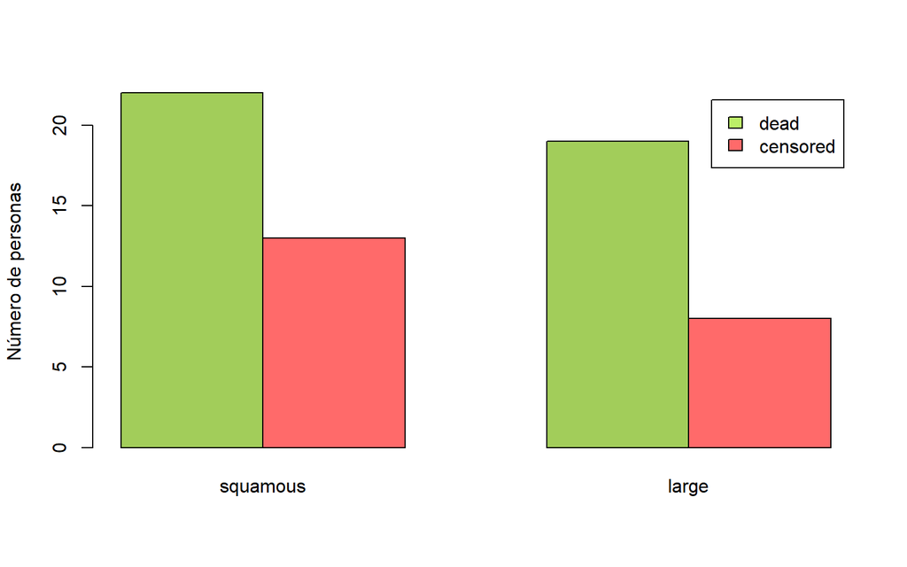

```r
barplot(survival4, beside=T, col=c("darkolivegreen3","indianred1"), ylab="Número de personas")
legend("topright", inset=.02, legend=c("dead","censored"), fill=c("darkolivegreen2", "indianred1"))
```

```r
prop.test(survival4, alternative="less",conf.level = 0.95)
```

```
##
##  2-sample test for equality of proportions with continuity correction
##
## data:  survival4
## X-squared = 0.12192, df = 1, p-value = 0.3635
## alternative hypothesis: less
## 95 percent confidence interval:
##  -1.0000000  0.1698566
## sample estimates:
##    prop 1    prop 2
## 0.5365854 0.6190476
```

El p.value no es significativo, por tanto aceptamos la hipótesis nula, es decir tenemos la misma proporción en los 2 tipos de célula.

### Small y large

[output not shown]

```r
barplot(survival5, beside=T, col=c("darkolivegreen3","indianred1"), ylab="Número de personas")
legend("topright", inset=.02, legend=c("dead","censored"), fill=c("darkolivegreen2", "indianred1"))
```

[output not shown]

```r
prop.test(survival5, alternative="less",conf.level = 0.95)
```

[output not shown]

## 3.2 Regresión logística

Ahora vamos a analizar la probabilidad de que fallezca un paciente antes o después (medido según el tiempo de tratamiento) y según el tipo de célula cancerígena que tenga. Primero hemos hecho la gráfica para ver más o menos qué tipo de células causan que los pacientes fallezcan antes. Hemos establecido como límite los 100 días de tratamiento, en los que se ve en la gráfica que prácticamente todo el mundo con la célula `Adeno`y la célula `Small` ha fallecido antes de ese número de días.

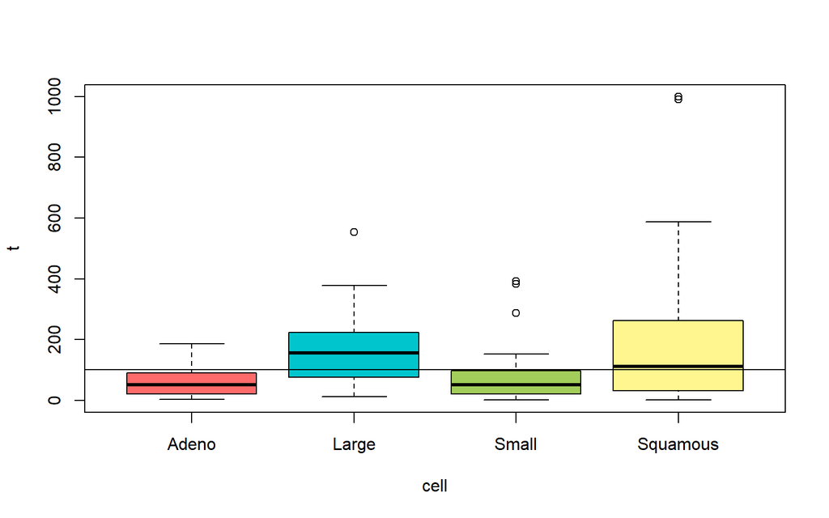

```r
boxplot(t~cell, data = valung, col = c("indianred1", "turquoise3", "darkolivegreen3", "khaki1"))
abline(h=100)
```

Para estimar esto, hemos decidido utilizar una regresión logística ya que el dato del tipo de célula no es numérico, y por tanto no podíamos hacer una regresión lineal. Hemos analizado si hay significancia estadística entre las muertes antes de los 100 días y el tipo de célula cancerígena que tienen los pacientes.

```
##
## Call:
## glm(formula = death_after_100_days ~ 0 + cell, family = "binomial",
##     data = valung)
##
## Deviance Residuals:
##     Min       1Q   Median       3Q      Max
## -1.8365  -1.0579   0.6400   0.6835   1.6431
##
## Coefficients:
##              Estimate Std. Error z value Pr(>|z|)
## cellAdeno      1.4816     0.4954   2.991 0.002785 **
## cellLarge     -1.0498     0.4392  -2.391 0.016823 *
## cellSmall      1.3350     0.3554   3.756 0.000172 ***
## cellSquamous  -0.2877     0.3416  -0.842 0.399650
## ---
## Signif. codes:  0 '***' 0.001 '**' 0.01 '*' 0.05 '.' 0.1 ' ' 1
##
## (Dispersion parameter for binomial family taken to be 1)
##
##     Null deviance: 189.92  on 137  degrees of freedom
## Residual deviance: 153.71  on 133  degrees of freedom
## AIC: 161.71
##
## Number of Fisher Scoring iterations: 4
```

# 4. Análisis de la influencia del desempeño de Karnofsky

El desempeño de Karnofsky, según el Instituto Nacional del Cáncer, es la forma estándar de medir la capacidad de los pacientes con cáncer de realizar tareas rutinarias (del 0 al 100) Un puntaje más alto significa que el paciente tiene mejor capacidad de realizar las actividades cotidianas. Se puede usar para determinar el pronóstico del paciente, medir los cambios en la capacidad del paciente para funcionar o decidir si un paciente puede ser incluido en un estudio clínico.

- La escala se puede resumir así:

  -100: Normal, sin quejas, sin indicios de enfermedad.

  -90: Actividades normales, pero con signos y síntomas leves de enfermedad.

  -80: Actividad normal con esfuerzo, con algunos signos y síntomas de enfermedad.

  -70: Capaz de cuidarse, pero incapaz de llevar a término actividades normales o trabajo activo.

  -60: Requiere atención ocasional, pero puede cuidarse a sí mismo.

  -50: Requiere gran atención, incluso de tipo médico. Encamado menos del 50% del día.

  -40: Inválido, incapacitado, necesita cuidados y atenciones especiales. Encamado más del 50% del día.

  -30: Inválido grave, severamente incapacitado, tratamiento de soporte activo.

  -20: Encamado por completo, paciente muy grave, necesita hospitalización y tratamiento activo.

  -10: Moribundo.

  -0 Fallecido
- Gráfica que muestra el Desempeño de Karnofsky (`KPS`) en función del tipo de terapia (`therapy`), así podemos ver que tipos de terapias parecen que mejoran la calidad de vida de los pacientes:

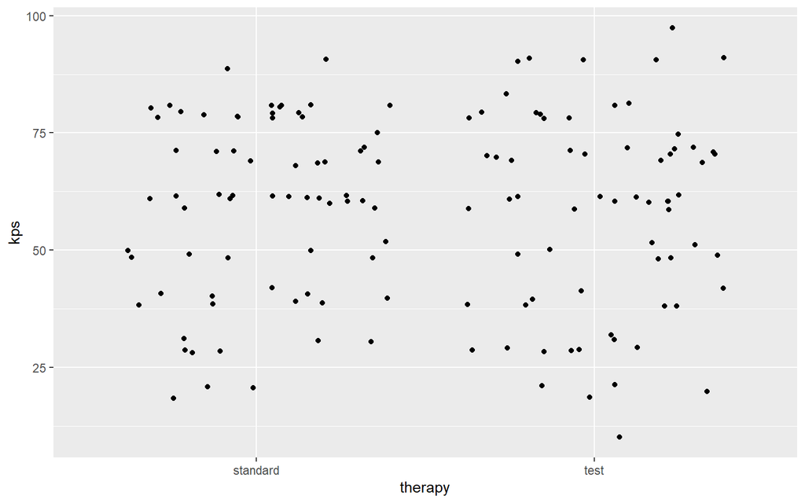

Según la gráfica parece que no hay mucha diferencia entre el tipo de tratamiento usado y el kps, como mucho se podría decir que la terapia test tiene mayor varianza, o sea que ha dado mejores y peores resultados en el Desempeño de Karnofsky.

- En este boxplot podemos ver qué tipo de células (`type`) afectan más a la calidad de vida de los pacientes, usando el Desempeño de Karnofsky (`kps`) para ello:

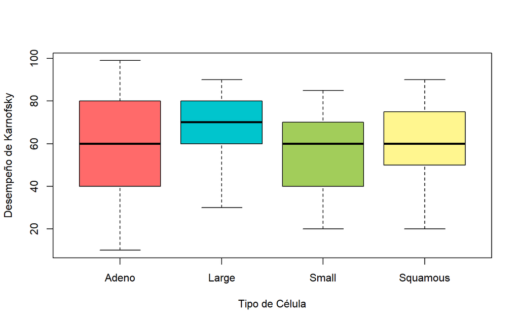

En el boxplot se puede ver que para los tipos de células Adeno, Small y Squamous la media en el Desempeño de Karnofsky es prácticamente la misma, rondando los 60, mientras que para el tipo Large, la media sube hasta aproximandamente los 70. Además, se puede ver claramente que el tipo Adeno tiene una varianza mayor que el resto, y que sus casos abarcan todos los puntos de la escala de kps. Por tanto, como vemos en la gráfica el tipo de célula Large es la menos agresiva contra el cuerpo, ya que los pacientes analizados con este tipo son los que tienen el mayor kps.

- En este boxplot podemos ver si el que haya habido un tratamiento previo (`prior`) afecta a la calidad de vida de los pacientes, usando el Desempeño de Karnofsky (`kps`) para ello:

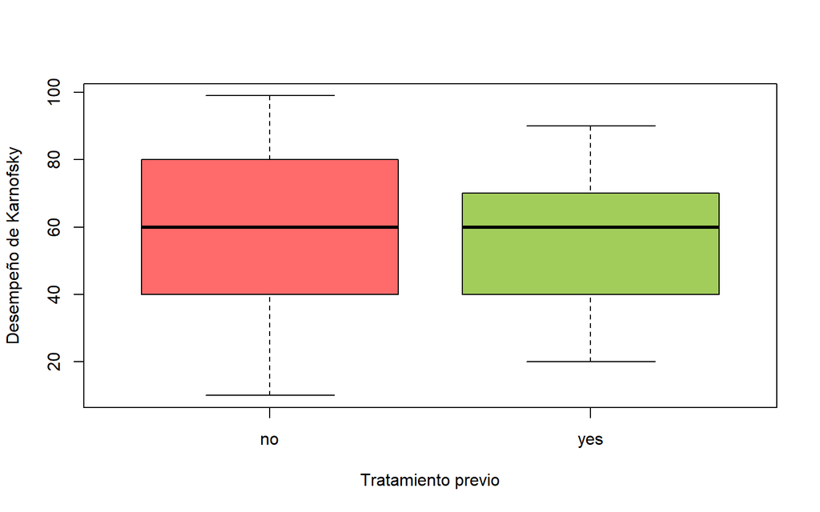

En esta gráfica se puede ver que aunque tengan la misma media, el caso en el que sí que haya habido un tratamiento previo tiene menos varianza en el kps, mientras que para los pacientes que no hayan tenido un tratamiento previo, hay una varianza mucho mayor, o sea que pueden haber casos con el kps muy alto o casos con el kps muy bajo, con el paciente prácticamente fallecido.

## 4.2. Relación del kps con el tiempo

### Kps en función del tiempo de tratamiento

-En esta gráfica se puede ver para los distintos tipos de célula (color) si el tiempo de seguimiento del tratamiento afecta a la calidad de vida (medida en el Desempeño de Karnofsky, `kps`):

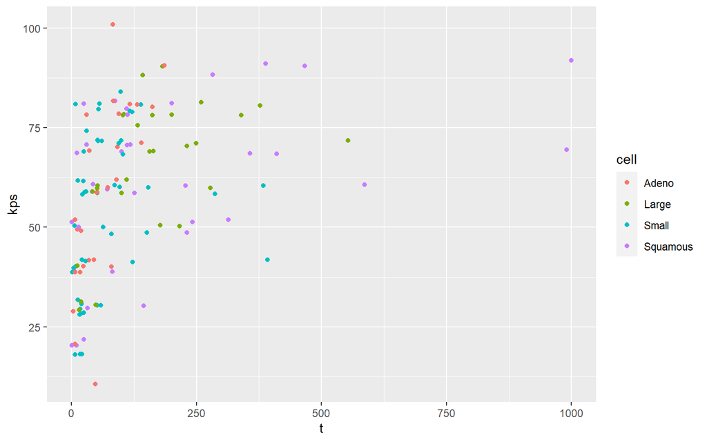

-Se puede ver lo mismo pero en gráficas separadas:

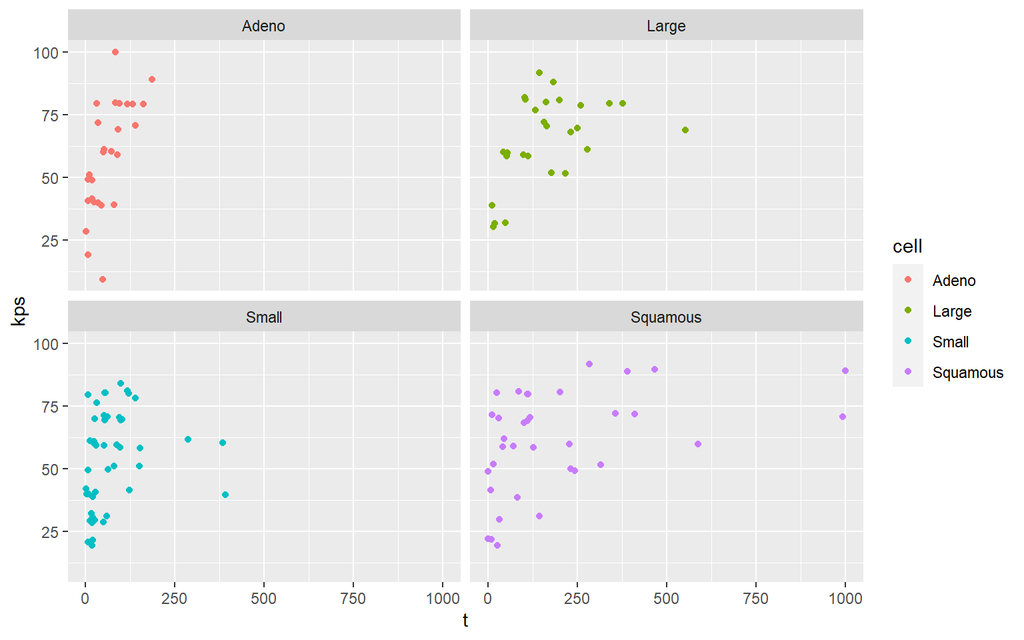

- En estas gráficas podemos ver que para la células Adeno y Small casi todos los casos muy variados de kps sólamente existen para tiempos de tratamiento muy cortos. Por tanto asumimos que no hay tiempos de tratamiento más prolongados porque el paciente falleció pronto. Para los otros 2 tipos de células: Large y especialmente Squamous, se puede ver que hay un poco más de variabilidad con el tiempo de tratamiento, y que los pacientes tardan un poco más en fallecer.
- Para analizar esto mejor, hemos hecho una regresión lineal simple para ver si hay significancia estadísitca entre el kps y el tiempo de tratamiento.

```
##
## Call:
## lm(formula = log2(t) ~ 0 + kps, data = valung)
##
## Residuals:
##     Min      1Q  Median      3Q     Max
## -4.7965 -0.9602 -0.0234  1.4033  4.7775
##
## Coefficients:
##     Estimate Std. Error t value Pr(>|t|)
## kps  0.09593    0.00251   38.22   <2e-16 ***
## ---
## Signif. codes:  0 '***' 0.001 '**' 0.01 '*' 0.05 '.' 0.1 ' ' 1
##
## Residual standard error: 1.818 on 136 degrees of freedom
## Multiple R-squared:  0.9148, Adjusted R-squared:  0.9142
## F-statistic:  1461 on 1 and 136 DF,  p-value: < 2.2e-16
```

- En el summary podemos ver que nos sale increíblemente significativo (p.value << 0,05), por tanto podemos rechazar rotundamente la H0 (el tiempo de tratamiento no afecta al kps) y aceptar la H1 (el tiempo de tratamiento afecta al kps). Además, podemos ver que el 91,48% de la varianza de t se explica por el kps (viendo el multiple r-squared), lo que es un valor muy alto y por tanto vemos que hay mucha relación.
- Ahora vamos a graficar la regresión lineal:

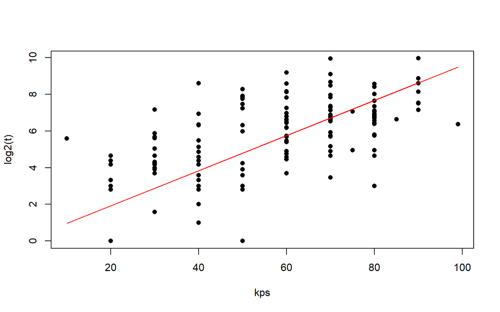

En esta gráfica podemos ver que hay una relación positiva entre el tiempo de tratamiento y el kps, para mayor tiempo de tratamiento, mayor kps. Por tanto, cuanto menor tiempo de tratamiento haya, más probabilidad de que haya un kps muy bajo.

### Kps en función del tiempo de diagnóstico

-En esta gráfica se puede ver lo mismo, pero en lugar del tiempo de seguimiento, hemos usado el tiempo de diagnosis:

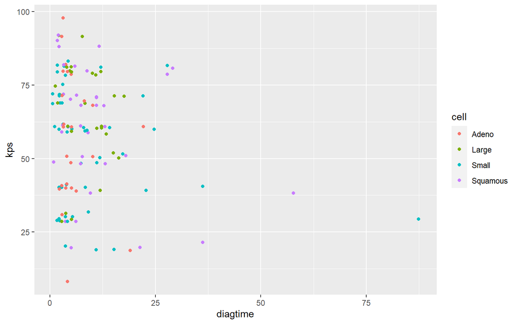

-Se puede ver lo mismo pero en gráficas separadas:

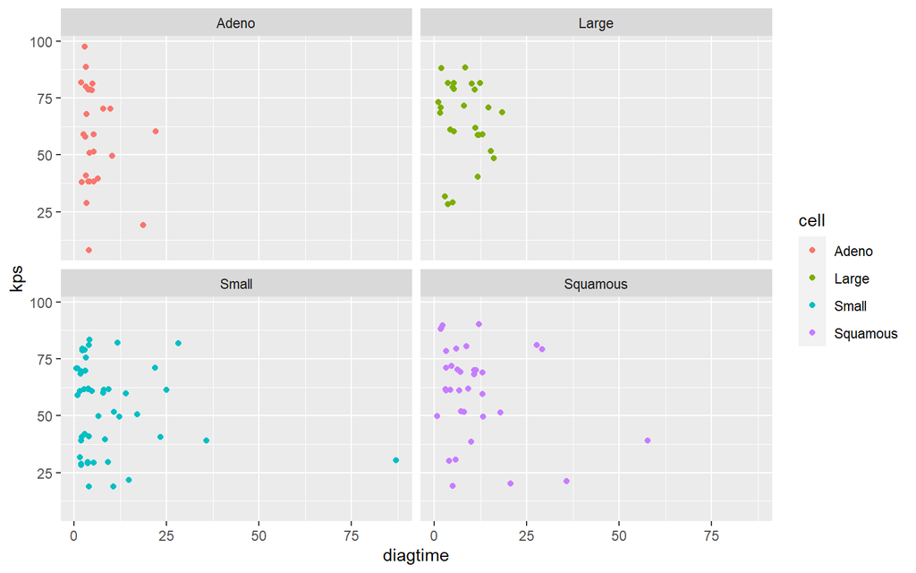

```
##
## Call:
## lm(formula = log2(diagtime) ~ 0 + kps, data = valung)
##
## Residuals:
##     Min      1Q  Median      3Q     Max
## -2.8197 -0.6857  0.4421  1.3292  5.3151
##
## Coefficients:
##     Estimate Std. Error t value Pr(>|t|)
## kps 0.037596   0.002229   16.87   <2e-16 ***
## ---
## Signif. codes:  0 '***' 0.001 '**' 0.01 '*' 0.05 '.' 0.1 ' ' 1
##
## Residual standard error: 1.614 on 136 degrees of freedom
## Multiple R-squared:  0.6766, Adjusted R-squared:  0.6742
## F-statistic: 284.6 on 1 and 136 DF,  p-value: < 2.2e-16
```

- En el summary podemos ver que también hay muchísima significancia estadística (p.value << 0,05), por tanto podemos rechazar la H0 (el tiempo de diagnóstico no afecta al kps) y aceptar la H1 (el tiempo de diagnosis afecta al kps). También podemos ver que el 67,66% de la varianza de diagtime se explica por el kps (viendo el multiple r-squared en el summary), lo que es un valor alto, pero menos que para el tiempo de tratamiento.
- Ahora vamos a graficar la regresión lineal:

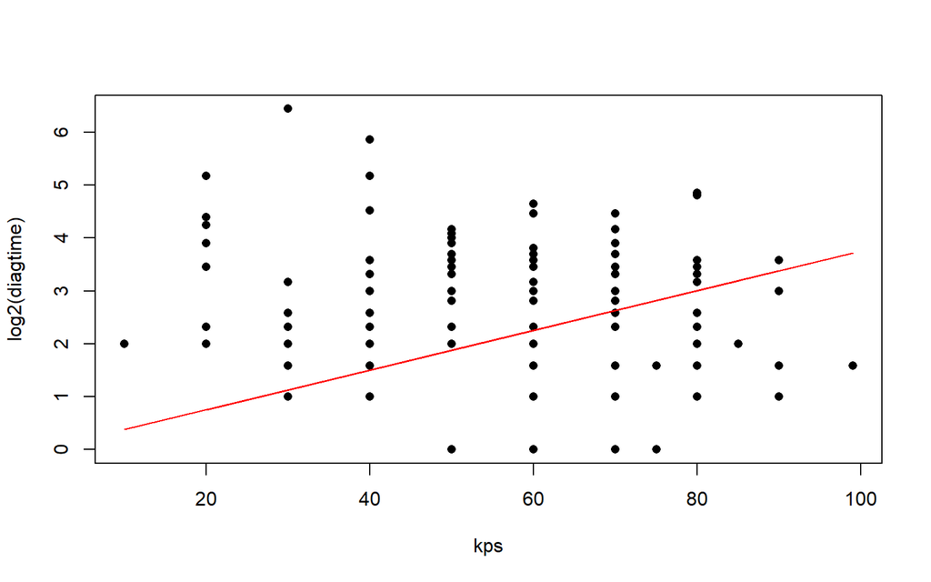

# 5. Análisis del tipo de terapia

## 5.1 Tipo de terapia según la edad y terapia previa

Hemos querido ver si había alguna relación entre el tipo de tratamiento usado y la edad del paciente y si además ha tenido un tratamiento previo.

Para poder relacionar estas variables hemos utilizado una regresión logística ya que 2 variables de las 3 utilizadas son de tipo binario y por tanto no se podía hacer una regresión lineal múltiple.

```r
# Regresión logística
y <- glm(formula = therapy ~ valung.prior + valung.age, data = valung2, family = "binomial")
summary(y)
```

```
##
## Call:
## glm(formula = therapy ~ valung.prior + valung.age, family = "binomial",
##     data = valung2)
##
## Deviance Residuals:
##    Min      1Q  Median      3Q     Max
## -1.323  -1.179  -1.020   1.157   1.350
##
## Coefficients:
##                 Estimate Std. Error z value Pr(>|z|)
## (Intercept)     -0.82277    0.99327  -0.828    0.407
## valung.prioryes -0.08830    0.37893  -0.233    0.816
## valung.age       0.01430    0.01648   0.868    0.385
##
## (Dispersion parameter for binomial family taken to be 1)
##
##     Null deviance: 189.92  on 136  degrees of freedom
## Residual deviance: 189.05  on 134  degrees of freedom
## AIC: 195.05
##
## Number of Fisher Scoring iterations: 3
```

Después de hacer la regresión logística, hemos concluido que no hay ninguna relación entre estas 3 variables, ya que ninguno de los p.values es significativo. Por tanto se puede decir que no hay variación en el tipo de terapia usada en el paciente según la edad que tenga o según si ya ha sido sometido a otra terapia anteriormente. Por tanto, no se tienen en cuenta ni la edad ni si ha habido una terapia previa a la hora de decidir qué tipo de tratamiento se usa.

## 5.2 Tipo de terapia según el tipo de célula cancerígena

Después de ver que no hay relación entre la terapia usada y la edad y si ha habido tratamiento previo, queríamos ver si hay alguna relación entre el tipo de tratamiento usado y el tipo de célula que tiene el paciente. Para ello, volvemos a usar una regresión logística, ya que no podemos estudiar esta relación con estas variables usando una regresión lineal.

```r
valung2 <- data.frame(datos, valung$age, valung$prior, valung$cell)
y <- glm(formula = therapy ~ valung.cell, data = valung2, family = "binomial")
summary(y)
```

```
##
## Call:
## glm(formula = therapy ~ valung.cell, family = "binomial", data = valung2)
##
## Deviance Residuals:
##     Min       1Q   Median       3Q      Max
## -1.4823  -1.0842  -0.9695   1.0579   1.4006
##
## Coefficients:
##                     Estimate Std. Error z value Pr(>|z|)
## (Intercept)           0.6931     0.4082   1.698   0.0895 .
## valung.cellLarge     -0.9163     0.5627  -1.628   0.1035
## valung.cellSmall     -1.2040     0.5055  -2.382   0.0172 *
## valung.cellSquamous  -0.4055     0.5323  -0.762   0.4462
## ---
## Signif. codes:  0 '***' 0.001 '**' 0.01 '*' 0.05 '.' 0.1 ' ' 1
##
## (Dispersion parameter for binomial family taken to be 1)
##
##     Null deviance: 189.92  on 136  degrees of freedom
## Residual deviance: 182.78  on 133  degrees of freedom
## AIC: 190.78
##
## Number of Fisher Scoring iterations: 4
```

A la vista de los resultados, se puede ver que sólo hay significancia estadística para la célula small, por tanto el único tipo de célula que tenemos que tener en cuenta a la hora de elegir el tipo de terapia es la célula small. Por ello, se puede rechazar la hipótesis nula de que el tratamiento no varía según el tipo de célula cancerígena, y podemos aceptar la hipótesis alternativa de que hay una relación entre el tipo de tratamiento usado y el tipo de célula tipo `small` .

# 6. Conclusiones

No hemos puesto otros tipos de tests porque el modelo de regresión lineal llega a las mismas conclusiones. Según las preguntas que nos hemos planteado antes, estas son nuestras conclusiones:

-¿Qué tipo de célula cancerígena es la más agresiva para el cuerpo? ¿Y la más letal?

Según las gráficas que hemos obtenido en los apartados anteriores, se puede ver que no hay ningún tipo de célula que claramente empeore el Desempeño de Karnofsky de los pacientes. En el boxplot que hemos hecho en el apartado 4 se puede ver, en cambio, que hay un tipo de célula que tiene mejor media de kps que el resto, y esa es la tipo Large. En el apartado 3.2 hemos analizado también qué tipo de células causan una muerte más rápida que otras, situando como límite los 100 días de tratamiento. En esta regresión hemos podido ver claramente como los tipos de células Adeno y Small son las que causan una altísima probabilidad de que un paciente con ellas muera antes de los 100 días de tratamiento.

¿Cómo influye el tiempo de diagnóstico? Y una vez diagnosticado, ¿cómo influye el tiempo de actuación?

En el apartado 4.2, hemos podido analizar la relación que existe entre el kps y el tiempo de diagnóstico y el kps y el tiempo de tratamiento. Al hacer una regresión lineal para cada variable comparado con el kps, Podemos observar que ambas son muy significativas y por tanto tanto el tiempo de diagnóstico como el tiempo de tratamiento están claramente relacionados. Por tanto, tanto el tiempo de diagnóstico como el tiempo de tratamiento influyen mucho en el Desempeño de Karnofsky que tiene el paciente en ese momento.

¿Se aplica algún criterio para elegir el tipo de tratamiento?

Como hemos podido observar en el último apartado, usando 2 regresiones logísticas hemos determinado que sí que se cambia el tipo de terapia según el tipo de célula cancerígena que tiene el paciente, pero la edad o si ha habido una terapia previa no son criterios adicionales para esta decisión. Por tanto, según lo que hemos podido analizar, el tipo de célula cancerígena es el único criterio para determinar el tipo de tratamiento usado.